# ASSESSOR: An age-structured state-space stock-recruit model for Pacific salmon

### Contributors

[**Mark D. Scheuerell**](https://faculty.washington.edu/scheuerl/)  
*Fish Ecology Division, Northwest Fisheries Science Center, National Marine Fisheries Service, National Oceanic and Atmospheric Administration, Seattle, WA USA, mark.scheuerell@noaa.gov*

**Casey P. Ruff**  
*Skagit River System Cooperative, Mt. Vernon, WA USA, cruff@skagitcoop.org*

**Eric R. Buhle**  
*Ocean Associates, Northwest Fisheries Science Center, National Marine Fisheries Service, National Oceanic and Atmospheric Administration, Seattle, WA USA, eric.buhle@noaa.gov*

[**James T. Thorson**](https://sites.google.com/site/thorsonresearch/)  
*Fishery Resource Analysis and Monitoring Division, Northwest Fisheries Science Center, National Marine Fisheries Service, National Oceanic and Atmospheric Administration, Seattle, WA USA, james.thorson@noaa.gov*

### Version

This is version 0.17.04.26.

## Overview

ASSESSOR incorporates data on spawners (escapement), harvest, and age composition into a retrospective run reconstruction and probabilistic forecast under a Bayesian framework. The general structure follows that of Fleischman et al. (2013), but ASSESSOR also allows for the inclusion of specific external drivers of productivity, both natural (e.g., climate variability) and anthropogenic (e.g., flow alteration). The model is composed of two primary pieces: a process model that governs the true population dynamics, and an observation model that relates the data in hand to the true process.

### Process component

We begin with our process model that describes the true, but unknown production of offspring from their parents. In any given year *t*, spawning adults produce some number of surviving offspring, which follows a general Ricker model, such that

$$\log(R_t) = \log(S_t) + a_t \ – bS_t + w_t.$$

Here $R_t$ is the total number of subsequent recruits (offspring) born in year *t*; $S_t$ is the true, but unobserved, number of spawning adults; $a_t$ is the annual density-independent productivity; $b$ is the strength of density dependence; and $w_t$ is a process error representing environmental stochasticity, which is autocorrelated over time according to $w_t \sim \text{N}(\phi w_{t-1}, q_a)$.

Previous applications of time-varying productivity (e.g., Peterman et al. 2003; Dorner et al. 2008) have used a Markov form where $a_t \sim \text{N}(a_{t-1}, \sigma_a)$, but we will model $(a_t)$ as a function of time-varying covariates. Specifically,

$$a_t = \bar{a} + \sum_{i=1}^{M} c_{i,t} \ X_{i,t+h}$$

Here $\bar{a}$ is the underlying mean productivity, and $c_{i,t}$ is the effect of covariate $i$ at time $t$, $X_{i,t+h}$. To allow for direct comparison of effect sizes, the covariates are typically standardized to have a zero mean and unit variance.

The estimated number of fish of age $a$ returning in year $t$ $(N_{a,t})$ is then product of the total number of brood-year recruits in year $t – a$ and the proportion of mature fish from that brood year that returned to spawn at age $a$ $(p_{a,t-a})$, such that

$$N_{a,t} = R_{t-a} \ p_{a,t-a}.$$

The vector of age-specific return rates for brood year $t$ $(\mathbf{p}_t)$ has length $A$, which equals the number of adult age classes. That is, $\mathbf{p}_t$ is a combination of the probability of surviving to, and maturing in years $t + a_\min$ to $t + a_\max$. We modeled $(\mathbf{p}_t)$ as a random effect using a hierarchical form of the Dirichlet distribution, where

$$\mathbf{p}_t \sim \text{Dirichlet}(\boldsymbol{\mu},\pi).$$

In this formulation, the mean vector $\boldsymbol{\mu}$ is itself distributed as a Dirichlet, and therefore has a total of $A$ elements that are all greater than zero. The precision parameter $\pi$ affects each of the elements in $\boldsymbol{\mu}$, such that large values of $\pi$ results in values of $\mathbf{p}_t$ that are very close to $\boldsymbol{\mu}$.

### Observation component

Estimates of the number of spawning adults necessarily contain some sampling or observation errors due to incomplete censuses, mis-identification, etc. Therefore, we will assume that the estimates of escapement $(E_t)$ are log-normally distributed about the true number of spawners $(S_t)$

$$\log(E_t) \sim \text{Normal}\left(\log(S_t), r_s\right).$$

We do not have the ability to estimate the observation variances for both the escapement and harvest without any additional prior information. Therefore, we will assume the harvest is recorded without error and calculate $S_t$ as the difference between the estimated total run size $(N_t)$ and harvest $(H_t)$

$$S_t = N_t - H_t.$$

and $N_t$ is the sum of $N_{a,t}$ over all age classes.

The age composition data include the number of fish in each age class $a$ in year $t$ $(O_{a,t})$. The age data are then modeled as a multinomial process with order $Y_t$ and proportion vector $\mathbf{d}_t$, such that

$$\mathbf{O}_t \sim \text{Multinomial}(Y_t, \mathbf{d}_t).$$

The order of the multinomial is simply the sum of the observed numbers of fish across all ages returning in year $t$:

$$Y_t = \sum_{a=a_\min}^{a_\max} O_{a,t}$$

The proportion vector $\mathbf{d}_t$ for the multinomial is based on the age-specific, model-derived estimates of adult returns in year $t$ $(N_{a,t})$, such that

$$d_{a,t} = {N_{a,t} \over \displaystyle \sum_{a=a_\min}^{a_\max} N_{a,t}}.$$

## Requirements

All analyses require the [R software](https://cran.r-project.org/) (v3.2.3) for data retrieval, data processing, and summarizing model results, and the [JAGS software](http://mcmc-jags.sourceforge.net/) (v4.2.0) for Markov chain Monte Carlo (MCMC) simulation. Please note that some of the R code below may not work with older versions of JAGS due to some changes in the ways that arrays are handled.

We also need a few packages that are not included with the base installation of R, so we begin by installing them (if necessary) and then loading them.

```r
if(!require("R2jags")) {
  install.packages("R2jags")
  library("R2jags")
}
if(!require("RCurl")) {
  install.packages("RCurl")
  library("RCurl")
}
if(!require("gsl")) {
  install.packages("gsl")
  library("gsl")
}
```

The last thing we’ll need is the following function for trimming real numbers to a desired precision when plotting output.

```r
Re2prec <- function(x,map="round",prec=1) {
  ## 'map' can be round, floor, or ceiling
  ## 'prec' is nearest value (eg, 0.1 means to nearest tenth); default 1 gives normal behavior
  if(prec<=0) { stop("\"prec\" cannot be less than or equal to 0") }
  do.call(map,list(x/prec))*prec
}
```

## User inputs

We begin by specifying the names of four necessary data files that contain the following information:

1. observed total number of adult spawners (escapement) by year;
2. observed age composition of adult spawners by year;
3. observed total harvest by year;
4. hatchery releases by year.

Let’s also define the following parameters, which will be referenced throughout the analysis.

- `n_yrs`: number of calendar years of data
- `A`: number of age classes
- `M`: number of covariates

```r
## 1. file with escapement data
## [n_yrs x 2] matrix of obs counts; 1st col is calendar yr
fn_esc <- "SkagitSthdEsc.csv"

## 2. file with age comp data
## [n_yrs x (1+A)]; 1st col is calendar yr
fn_age <- "SkagitSthdAge.csv"
## min & max ages
age_min <- 3
age_max <- 8
## years, if any, of age-comp to skip; see below
age_skip <- 2

## 3. file with harvest data
## [n_yrs x 2] matrix of obs catch; 1st col is calendar yr
fn_harv <- "SkagitSthdCatch.csv"

## 4. file with covariate data
## [n_yrs x (1+MM)]; 1st col is calendar yr
fn_hrel <- "SkagitHatchRel.csv"

## time lags (years) for covariates
flow_lag <- 1
marine_lag <- 2
hrel_lag <- 2

## number of years of forecasts
n_fore <- 1

## file where to save JAGS model
fn_jags <- "SkagitSthd_RR_JAGS.txt"

## upper threshold for Gelman & Rubin's (1992) potential scale reduction factor (Rhat).
Rhat_thresh <- 1.1

## URL for example data files
## set to NULL if using a local folder/directory
ex_url <- "https://raw.githubusercontent.com/mdscheuerell/ASSESSOR/master/datafiles/"
```

## Loading the fish data

Here we load in the first three data files and do some simple calculations and manipulations. First the spawner data:

```r
## escapement
dat_esc <- read.csv(text = getURL(paste0(ex_url,fn_esc)))
## years of data
dat_yrs <- dat_esc$year
## number of years of data
n_yrs <- length(dat_yrs)
## get first & last years
yr_frst <- min(dat_yrs)
yr_last <- max(dat_yrs)
## log of escapement
ln_dat_esc <- c(log(dat_esc[,-1]),rep(NA,n_fore))
```

Next the age composition data:

```r
## age comp data
dat_age <- read.csv(text = getURL(paste0(ex_url,fn_age)))
## drop year col & first age_min+age_skip rows
dat_age <- dat_age[-(1:(age_min+age_skip)),-1]
## num of age classes
A <- age_max-age_min+1
## add row(s) of NA's for forecast years
dat_age <- rbind(dat_age,matrix(0,n_fore,A,dimnames=list(n_yrs+seq(n_fore),colnames(dat_age))))
## total num of age obs by cal yr
dat_age[,"sum"] <- apply(dat_age,1,sum)
## row indices for any years with no obs age comp
idx_NA_yrs <- which(dat_age$sum<A,TRUE)
## replace 0's in yrs w/o any obs with NA's
dat_age[idx_NA_yrs,(1:A)] <- NA
## change total in yrs w/o any obs from 0 to A to help dmulti()
dat_age[idx_NA_yrs,"sum"] <- A
## convert class
dat_age <- as.matrix(dat_age)
```

And then the harvest data:

```r
## harvest
dat_harv <- read.csv(text = getURL(paste0(ex_url,fn_harv)))
## drop year col & first age_max rows
dat_harv <- c(dat_harv[,-1],rep(0,n_fore))
```

## Loading the covariates

### River discharge

```r
## flow site
flow_site <- 12178100
## get URL for flow data from USGS
flow_url <- paste0("https://waterdata.usgs.gov/nwis/dv",
                   "?cb_00060=on",
                   "&format=rdb",
                   "&site_no=",flow_site,
                   "&begin_date=",yr_frst,"-01-01",
                   "&end_date=",yr_last,"-12-31")
```

Next we will retrieve the raw data file and print its metadata.

```r
## raw flow data from USGS
flow_raw <- readLines(flow_url)
## lines with metadata
hdr_flow <- which(lapply(flow_raw,grep,pattern="\\#")==1, arr.ind=TRUE)
## print flow metadata
print(flow_raw[hdr_flow],quote=FALSE)
```

```
##  [1] # ---------------------------------- WARNING ----------------------------------------
##  [2] # Some of the data that you have obtained from this U.S. Geological Survey database
##  [3] # may not have received Director's approval. Any such data values are qualified
##  [4] # as provisional and are subject to revision. Provisional data are released on the
##  [5] # condition that neither the USGS nor the United States Government may be held liable
##  [6] # for any damages resulting from its use.
##  [7] #
##  [8] # Additional info: https://help.waterdata.usgs.gov/policies/provisional-data-statement
##  [9] #
## [10] # File-format description:  https://help.waterdata.usgs.gov/faq/about-tab-delimited-output
## [11] # Automated-retrieval info: https://help.waterdata.usgs.gov/faq/automated-retrievals
## [12] #
## [13] # Contact:   gs-w_support_nwisweb@usgs.gov
## [14] # retrieved: 2017-04-26 14:44:50 EDT       (caww02)
## [15] #
## [16] # Data for the following 1 site(s) are contained in this file
## [17] #    USGS 12178100 NEWHALEM CREEK NEAR NEWHALEM, WA
## [18] # -----------------------------------------------------------------------------------
## [19] #
## [20] # Data provided for site 12178100
## [21] #            TS   parameter     statistic     Description
## [22] #        149343       00060     00003     Discharge, cubic feet per second (Mean)
## [23] #
## [24] # Data-value qualification codes included in this output:
## [25] #     A  Approved for publication -- Processing and review completed.
## [26] #     e  Value has been estimated.
## [27] #
```

Lastly, we will extract the actual flow data for the years of interest and inspect the file contents.

```r
## flow data for years of interest
dat_flow <-  read.csv(textConnection(flow_raw[-c(hdr_flow,max(hdr_flow+2))]),
                      header=TRUE, stringsAsFactors=FALSE, sep="\t")
colnames(dat_flow) <- unlist(strsplit(tolower(flow_raw[max(hdr_flow)+1]), split="\\s+"))
head(dat_flow)
```

```
##   agency_cd  site_no   datetime 149343_00060_00003 149343_00060_00003_cd
## 1      USGS 12178100 1978-01-01                 58                     A
## 2      USGS 12178100 1978-01-02                 55                     A
## 3      USGS 12178100 1978-01-03                 56                     A
## 4      USGS 12178100 1978-01-04                 66                     A
## 5      USGS 12178100 1978-01-05                 90                     A
## 6      USGS 12178100 1978-01-06                 87                     A
```

The first 3 columns in the data file are the agency (`agency_cd`), location (`site_no`), and date (`datetime`). The daily flow measurements are in the 4th column (`149343_00060_00003`), so we will only keep `datetime` and `149343_00060_00003`, and rename them to `date` and `flow`, respectively. We will also convert the units from “cubic feet per second” to “cubic meters per second”.

```r
## keep only relevant columns
dat_flow <- dat_flow[c("datetime",grep("[0-9]$",colnames(dat_flow),value=TRUE))]
## nicer column names
colnames(dat_flow) <- c("date","flow")
## convert cubic feet to cubic meters
dat_flow$flow <- dat_flow$flow / 35.3147
## flow by year & month
dat_flow[,"year"] <- as.integer(sub("^([0-9]{4})-([0-9]{2})-([0-9]{2})","\\1",
                                    dat_flow[,"date"]))
dat_flow[,"month"] <- as.integer(sub("^([0-9]{4})-([0-9]{2})-([0-9]{2})","\\2",
                                     dat_flow[,"date"]))
dat_flow <- dat_flow[,c("year","month","flow")]
```

#### Winter maximum

We are interested in the maximum of the daily peak flows from October through March during the first year that juveniles are rearing in streams. This means we need to combine flow values for the fall of year $t$ with those in the spring of year $t+1$. Therefore, the flow time series will begin in `` yr_frst = 1978`; the last year of flow data will then be ``yr_last - age_min + n_fore + flow_lag = 2014`.

```r
## autumn flows in year t
flow_aut <- subset(dat_flow, (month>=10 & month<=12)
                   & year >= yr_frst & year <= yr_last-age_min+n_fore)
## spring flows in year t+1
flow_spr <- subset(dat_flow, (month>=1 & month<=3)
                   & year >= yr_frst+flow_lag & year <= yr_last-age_min+n_fore+flow_lag)
## change spr year index to match aut
flow_spr[,"year"] <- flow_spr[,"year"] - flow_lag
## combined flows indexed to brood year and calculate max flow over time period
dat_flow_wtr <- aggregate(flow ~ year, data=rbind(flow_aut,flow_spr), max)
## change year index to brood year
dat_flow_wtr[,"year"] <- dat_flow_wtr[,"year"]
## for plotting purpose later
colnames(dat_flow_wtr)[2] <- "Winter"
```

#### Summer minimum

Now we will calculate the minimum flow juveniles would experience during their first summer (June through September).

```r
## summer flows in year t
flow_sum <- subset(dat_flow, (month>=6 & month<=9)
                   & year >= yr_frst+flow_lag & year <= yr_last-age_min+n_fore+flow_lag)
## change year index to brood year
flow_sum[,"year"] <- flow_sum[,"year"] - flow_lag
## combined flows indexed to brood year and calculate max flow over time period
dat_flow_sum <- aggregate(flow ~ year, data=flow_sum, min)
## for plotting purpose later
colnames(dat_flow_sum)[2] <- "Summer"
```

### North Pacific Gyre Oscillation

We used the monthly NPGO data provided by Emanuele Di Lorenzo, which are available [here](http://www.o3d.org/npgo/npgo.php). We begin by downloading the raw NPGO data and viewing the metadata.

```r
## URL for NPGO data
url_NPGO <- "http://www.o3d.org/npgo/npgo.php"
## raw NPGO data
NPGO_raw <- readLines(url_NPGO)
## line with data headers
hdr_NPGO <- which(lapply(NPGO_raw,grep,pattern="YEAR")==1, arr.ind=TRUE)
## print PDO metadata
print(NPGO_raw[seq(hdr_NPGO)],quote=FALSE)
```

```
##  [1]
##  [2] <html>
##  [3] <body>
##  [4]
##  [5] <pre>#  Last update 29-Mar-2017 by E. Di Lorenzo
##  [6] #  NPGO index monthly averages
##  [7] #  from Jan-1950  to  Feb-2017
##  [8] #
##  [9] #  WARNING: Values after Dec-2004 are updated
## [10] #  using Satellite SSHa from AVISO Delayed Time product.
## [11] #  http://opendap.aviso.oceanobs.com/thredds/dodsC/dataset-duacs-dt-global-allsat-msla-h
## [12] #
## [13] #  PRELIMINARY: Values after Jan-2016 are preliminary and updated
## [14] #  using Satellite SSHa from AVISO Near Real Time product.
## [15] #  http://opendap.aviso.oceanobs.com/thredds/dodsC/dataset-duacs-nrt-over30d-global-allsat-msla-h
## [16] #
## [17] #  The update is performed by taking the NPGO spatial pattern of Di Lorenzo et al. 2008
## [18] #  computed over the period 1950-2004, and projecting the AVISO Satellite SSHa.
## [19] #  During the pre-processing of the AVISO data, we remove the seasonal cycle based on
## [20] #  the 1993-2004 seasonal means.
## [21] #
## [22] #  AVISO PRODUCT UPDATE Summer 2014: AVISO has released a re-processed dataset for the sea level.
## [23] #  Starting from the November 2014, the NPGO index is computed with this updated dataset. NPGO
## [24] #  values from 2004 onward have been recomputed with very minor differences from previous releases.
## [25] #
## [26] #  Ref:
## [27] #  Di Lorenzo et al., 2008: North Pacific Gyre Oscillation
## [28] #  links ocean climate and ecosystem change, GRL.
## [29] #
## [30] #      YEAR            MONTH        NPGO index
```

Next, we will extract the actual NPGO indices for the years of interest and inspect the file contents. We also want the average NPGO annual index from January 1 through December 31 during the first year that the juvenile steelhead are in the ocean (i.e., during their second year of life). Therefore, we need NPGO values from `yr_frst + marine_lag` = 1980 through `yr_last - age_min + n_fore + marine_lag` = 2015.

```r
## NPGO data for years of interest
dat_NPGO<- read.table(url_NPGO, header=FALSE, stringsAsFactors=FALSE,
                      skip=hdr_NPGO + (yr_frst-1950)*12, nrows = n_yrs*12)
colnames(dat_NPGO) <- c("year","month","NPGO")

## select only years of interest indexed by brood year
dat_NPGO <- dat_NPGO[dat_NPGO$year >= yr_frst+marine_lag &
                     dat_NPGO$year <= yr_last-age_min+n_fore+marine_lag,]
dat_NPGO <- aggregate(dat_NPGO$NPGO, by = list(year = dat_NPGO$year), FUN = mean)
dat_NPGO <- data.frame(year=seq(yr_frst,yr_last-age_min+n_fore), NPGO=dat_NPGO[,2])
colnames(dat_NPGO) <- c("year","NPGO")
dat_NPGO
```

```
##    year        NPGO
## 1  1978 -0.74910728
## 2  1979 -0.22184056
## 3  1980 -0.68669138
## 4  1981 -0.09206469
## 5  1982  0.62075004
## 6  1983 -0.39390105
## 7  1984 -0.73284729
## 8  1985  0.42917473
## 9  1986  1.32363676
## 10 1987  0.61224062
## 11 1988 -0.20154612
## 12 1989 -0.49891471
## 13 1990 -1.09491887
## 14 1991 -1.90199259
```

[output cut: 22 more lines]

### Spring Transition Index

We calculated the spring transition index (STI) from the daily coastal upwelling index (CUI) provided by NOAA’s Pacific Fisheries Environmental Laboratory ([PFEL](https://www.pfeg.noaa.gov/)); you can find more information [here](https://www.pfeg.noaa.gov/products/PFEL/modeled/indices/PFELindices.html). We begin by downloading the raw CUI data and viewing the metadata.

```r
## URL for CUI data
url_CUI <- "https://www.pfeg.noaa.gov/products/PFELData/upwell/daily/p06dayac.all"
## raw CUI data from PFEL
CUI_raw <- readLines(url_CUI)
## line with data headers
hdr_CUI <- which(lapply(CUI_raw,grep,pattern="YYYYMMDD")==1, arr.ind=TRUE)
## print CUI metadata
print(CUI_raw[seq(hdr_CUI-1)],quote=FALSE)
```

```
## [1] Bakun Index Values from NOAA/NMFS/PFEG for: 48N 125W
## [2] Values are daily average of wind-driven crossshore transports computed from
## [3] FNMOC six-hourly surface pressure analyses.  Indices are in units of cubic
## [4] meters per second along each 100 meters of coastline.  -9999 indicates missing
## [5] value.  Positive numbers indicate offshore transport.  Day is based on PST.
```

```r
## get daily CUI data
dat_CUI <- read.table(url_CUI, header=TRUE, stringsAsFactors=FALSE, skip=hdr_CUI-1)
## extract year from date
dat_CUI$yr <- gsub("[0-9]{4}$","",dat_CUI$YYYYMMDD)
## select only years of interest
cui <- dat_CUI[dat_CUI$yr >= yr_frst+marine_lag & dat_CUI$yr <= yr_last-age_min+n_fore+marine_lag,]
## calculate cumulative upwelling by year
cum_CUI <- tapply(cui[,"Index"], cui$yr, cumsum)
## function to return spring transition index
get_STI <- function(x, day_max=200) {
    return(min(which(x==min(x[1:day_max]))))
}
## calc STI for each year
dat_STI <- data.frame(year=seq(yr_frst,yr_last-age_min+n_fore),STI=sapply(cum_CUI,get_STI))
```

### Hatchery releases

The numbers of hatchery fish released each year is listed in a file on the project site. They have already been lagged 2 years (i.e., brood year + 2) to account for the potential competitive interactions during their juvenile life stage. (We will divide the release number by 1000 for plotting purposes.)

```r
dat_hrel <- read.csv(text = getURL(paste0(ex_url,fn_hrel)))
dat_hrel
```

```
##    year   Hrel
## 1  1978 340416
## 2  1979 274090
## 3  1980 216537
## 4  1981 300942
## 5  1982 241931
## 6  1983 256238
## 7  1984 319220
## 8  1985 125280
## 9  1986 229013
## 10 1987 217948
## 11 1988 226771
## 12 1989 205732
## 13 1990 154815
## 14 1991 375642
```

[output cut: 22 more lines]

### Combine all covariates

The last thing we will do is combine the covariates into one file and standardize them to have zero-mean and unit-variance.

```r
## covariate(s)
dat_cvrs <- Reduce(function(...) merge(..., all=T),
                   list(dat_flow_wtr,dat_flow_sum,dat_NPGO,dat_STI,dat_hrel))
## drop year col
dat_cvrs <- dat_cvrs[,-1]
## transform the covariates to z-scores
scl_cvrs <- scale(dat_cvrs)
## total number of covariates
n_cov <- dim(scl_cvrs)[2]
```

## Specifying model in JAGS

```r
cat("

model {

    ##--------
    ## PRIORS
    ##--------
    ## alpha = exp(a) = intrinsic productivity
    mu_Rkr_a ~ dnorm(0,1e-3)I(-4,4);
    alpha <- exp(mu_Rkr_a);
    E_Rkr_a <- mu_Rkr_a + var_Qr/(2 - 2*phi^2);

    ## covariate effects
    for(i in 1:n_cov) { cc[i] ~ dnorm(0,0.001) }

    ## strength of dens depend
    Rkr_b ~ dunif(0,0.1);

    ## AR(1) coef for proc errors
    phi ~ dunif(-0.999,0.999);

    ## process variance for recruits model
    sd_Qr ~ dunif(0.001,20);
    tau_Qr <- pow(sd_Qr,-2);
    var_Qr <- pow(sd_Qr,2)

    ## innovation in first year
    innov_1 ~ dnorm(0,tau_Qr*(1-phi*phi));

    ## obs variance for spawners
    sd_Rs ~ dunif(0.001,20);
    tau_Rs <- pow(sd_Rs,-2);
    var_Rs <- pow(sd_Rs,2)

    ## unprojectable early recruits;
    ## hyper mean across all popns
    Rec_mu ~ dnorm(0,0.001);
    ## hyper SD across all popns
    Rec_sig ~ dunif(0,100);
    ## precision across all popns
    Rec_tau <- pow(Rec_sig,-2);
    ## multipliers for unobservable total runs
    ttl_run_mu ~ dunif(1,5);
    ttl_run_tau ~ dunif(1,20);

    ## maturity schedule
    ## unif vec for Dirch prior
    for(i in 1:A) { theta[i] <- 1 }
    ## hyper-mean for maturity
    p_mu ~ ddirch(theta);
    ## hyper-prec for maturity
    p_pi ~ dunif(0.001,1e3);
    for(t in 1:(n_yrs-age_min+n_fore)) { p_vec[t,1:A] ~ ddirch(p_mu*p_pi) }

    ##------------
    ## LIKELIHOOD
    ##------------
    ## 1st brood yr requires different innovation
    ## predicted recruits in BY t
    covar[1] <- inprod(cc,scl_cvrs[1,]);
    ln_Rkr_a[1] <- mu_Rkr_a + covar[1];
    E_ln_Rec[1] <- ln_Sp[1] + ln_Rkr_a[1] - Rkr_b*Sp[1] + phi*innov_1;
    tot_ln_Rec[1] ~ dnorm(E_ln_Rec[1],tau_Qr);
    res_ln_Rec[1] <- tot_ln_Rec[1] - E_ln_Rec[1];
    ## median of total recruits
    tot_Rec[1] <- exp(tot_ln_Rec[1]);

    ## R/S
    ln_RS[1] <- tot_ln_Rec[1] - ln_Sp[1];

    ## brood-yr recruits by age
    for(a in 1:A) { Rec[1,a] <- max(1,tot_Rec[1] * p_vec[1,a]) };

    ## brood years 2:(n_yrs-age_min)
    for(t in 2:(n_yrs-age_min+n_fore)) {
        ## predicted recruits in BY t
        covar[t] <- inprod(cc,scl_cvrs[t,]);
        ln_Rkr_a[t] <- mu_Rkr_a + covar[t];
        E_ln_Rec[t] <- ln_Sp[t] + ln_Rkr_a[t] - Rkr_b*Sp[t] + phi*res_ln_Rec[t-1];
        tot_ln_Rec[t] ~ dnorm(E_ln_Rec[t],tau_Qr);
        res_ln_Rec[t] <- tot_ln_Rec[t] - E_ln_Rec[t];
        ## median of total recruits
        tot_Rec[t] <- exp(tot_ln_Rec[t]);
        ## R/S
        ln_RS[t] <- tot_ln_Rec[t] - ln_Sp[t];
        ## brood-yr recruits by age
        for(a in 1:A) { Rec[t,a] <- max(1,tot_Rec[t] * p_vec[t,a]) };
    } ## end t loop over year

    ## get total cal yr returns for first age_min yrs
    for(i in 1:(age_min+age_skip)) {
        ln_tot_Run[i] ~ dnorm(ttl_run_mu*Rec_mu,Rec_tau/ttl_run_tau);
        tot_Run[i] <- exp(ln_tot_Run[i]);
    }

    ## get predicted calendar year returns by age
    ## matrix Run has dim [(n_yrs-age_min) x A]
    ## step 1: incomplete early broods
    ## first cal yr of this grp is first brood yr + age_min + age_skip
    for(i in 1:(age_max-age_min-age_skip)) {
        ## projected recruits
        for(a in 1:(i+age_skip)) { Run[i,a] <- Rec[(age_skip+i)-a+1,a] };
        ## imputed recruits
        for(a in (i+1+age_skip):A) {
            lnRec[i,a] ~ dnorm(Rec_mu,Rec_tau);
            Run[i,a] <- exp(lnRec[i,a]);
        }
        ## total run size
        tot_Run[i+age_min+age_skip] <- sum(Run[i,1:A]);
        ## predicted age-prop vec for multinom
        for(a in 1:A) { age_v[i,a] <- Run[i,a] / tot_Run[i+age_min] };
        ## multinomial for age comp
        dat_age[i,1:A] ~ dmulti(age_v[i,1:A],dat_age[i,A+1]);
        lp_age[i] <- logdensity.multi(dat_age[i,1:A],age_v[i,1:A],dat_age[i,A+1]);
    } ## end step 1

    ## step 2: info from complete broods
    ## first cal yr of this grp is first brood yr + age_max
    for(i in (A-age_skip):(n_yrs-age_min-age_skip+n_fore)) {
        for(a in 1:A) { Run[i,a] <- Rec[(age_skip+i)-a+1,a] };
        ## total run size
        tot_Run[i+age_min+age_skip] <- sum(Run[i,1:A]);
        ## predicted age-prop vec for multinom
        for(a in 1:A) { age_v[i,a] <- Run[i,a] / tot_Run[i+age_min] };
        ## multinomial for age comp
        dat_age[i,1:A] ~ dmulti(age_v[i,1:A],dat_age[i,A+1]);
        lp_age[i] <- logdensity.multi(dat_age[i,1:A],age_v[i,1:A],dat_age[i,A+1]);
    }

    ## get predicted calendar year spawners
    ## first cal yr is first brood yr
    for(t in 1:(n_yrs+n_fore)) {
        ## obs model for spawners
    Sp[t] <- max(1,tot_Run[t] - dat_harv[t]);
        ln_Sp[t] <- log(Sp[t]);
        ln_dat_esc[t] ~ dnorm(ln_Sp[t], tau_Rs);
        lp_esc[t] <- logdensity.norm(ln_dat_esc[t],ln_Sp[t], tau_Rs);
    } ## end step 2

} ## end model description

", file=fn_jags)
```

## Fitting the model

The last thing we need to do before fitting the model in JAGS is to specify:

1. the data and indices that go into the model;
2. the model parameters and states that we want JAGS to return;
3. the MCMC control parameters.

Please note that the following code takes ~20 min to run on a quad-core machine with 3.5 GHz Intel processors.

```r
## data to pass to JAGS
dat_jags <- c("dat_age","ln_dat_esc","dat_harv","scl_cvrs","n_cov",
              "n_yrs","A","age_min","age_max","age_skip","n_fore")

## 2. model params/states for JAGS to return
par_jags <- c("alpha","E_Rkr_a","mu_Rkr_a","Rkr_b","ln_Rkr_a",
              "cc","lp_age","lp_esc",
              "Sp","Rec","tot_ln_Rec","ln_RS","p_vec",
              "var_Qr","var_Rs","res_ln_Rec")

## 3. MCMC control params
## MCMC parameters
mcmc_chains <- 4
mcmc_length <- 5e5
mcmc_burn <- 2.5e5
mcmc_thin <- 500
## total number of MCMC samples
mcmc_samp <- (mcmc_length-mcmc_burn)*mcmc_chains/mcmc_thin

## function to create JAGS inits
init_vals <- function() {
    list(mu_Rkr_a=1, cc=rnorm(n_cov,0,0.1),
         Rkr_b=1/exp(mean(ln_dat_esc, na.rm=TRUE)),
         p_pi=1, p_mu=rep(1,A),
         p_vec=matrix(c(0.01,0.3,0.48,0.15,0.05,0.01),n_yrs-age_min+n_fore,A,byrow=TRUE),
         Rec_mu=log(1000),
         Rec_sig=0.1,
         tot_ln_Rec=rep(log(1000),n_yrs-age_min+n_fore),
         innov_1=0,
         phi=0.5)
    }

## list of model info for JAGS
mod_jags <- list(data=dat_jags,
                 inits=init_vals,
                 parameters.to.save=par_jags,
                 model.file=fn_jags,
                 n.chains=as.integer(mcmc_chains),
                 n.iter=as.integer(mcmc_length),
                 n.burnin=as.integer(mcmc_burn),
                 n.thin=as.integer(mcmc_thin),
                 DIC=TRUE)

## fit the model in JAGS & store results
mod_fit <- do.call(jags.parallel, mod_jags)
```

## Model diagnostics

Here is a histogram of the Gelman & Rubin statistics $(R_{hat})$ for the estimated parameters. Recall that we set an upper threshold of 1.1, so values larger than that deserve some additional inspection.

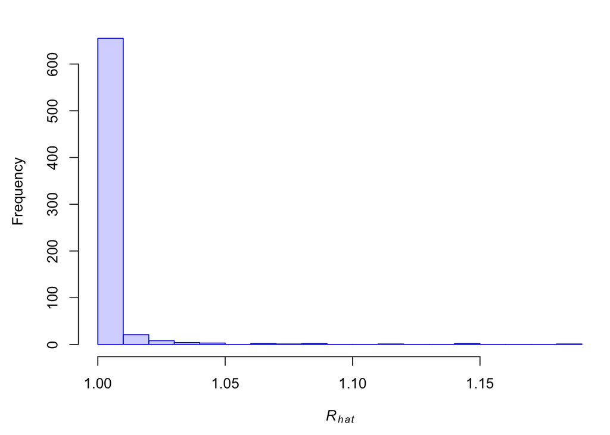

```r
## Rhat values for all parameters
rh <- mod_fit$BUGSoutput$summary[,"Rhat"]
## histogram of Rhat values for all parameters
par(mai=c(0.9,0.9,0.3,0.1))
hist(rh, breaks=seq(1,ceiling(max(rh)/0.01)*0.01,by=0.01),main="",
     col=rgb(0,0,255,alpha=50,maxColorValue=255),border="blue3",xlab=expression(italic(R[hat])))
```

```r
## Rhat values > threshold
bad_Rhat <- rh[rh>Rhat_thresh]
## prop of params with Rhat > threshold
round(length(bad_Rhat)/length(rh),3)
```

```
## [1] 0.006
```

```r
## param names
par_names <- sub("\\[.*","",names(bad_Rhat))
## number of Rhat > threshold by param name
table(par_names)
```

```
## par_names
## p_vec
##     4
```

```r
## index values for offenders
idx <- as.integer(sub("(^.*\\[)([0-9]{1,3})(.*)","\\2",names(bad_Rhat)))
## data frame of offenders
(df <- data.frame(par=par_names, index=idx))
```

```
##     par index
## 1 p_vec     4
## 2 p_vec    22
## 3 p_vec    29
## 4 p_vec    32
```

The convergence statistics indicate that some of the elements in $p$ for the estimated proportions of the youngest and oldest age classes (i.e., 3 and 8, respectively) did not converge to our desired threshold. However, there is very little data to inform those parameters, so we should not be too concerned.

## Main results

Here is a table of summary statistics for some of the model parameters.

```r
tbl_smry <- mod_fit$BUGSoutput$summary[c("E_Rkr_a","Rkr_b",
                                         paste0("cc[",seq(n_cov),"]"),
                                         "var_Qr","var_Rs"),
                                       c("mean","sd","2.5%","50%","97.5%")]
rownames(tbl_smry)[seq(n_cov)+2] <- colnames(dat_cvrs)
print(tbl_smry,digits=3,quote=FALSE,justify="right")
```

```
##              mean       sd      2.5%       50%     97.5%
## E_Rkr_a  1.148282 3.60e-01  5.14e-01  1.134268  1.790775
## Rkr_b    0.000128 4.45e-05  4.23e-05  0.000127  0.000216
## Winter  -0.154901 7.58e-02 -3.04e-01 -0.154136 -0.001472
## Summer   0.022756 7.08e-02 -1.11e-01  0.021019  0.166034
## NPGO     0.098842 9.74e-02 -9.01e-02  0.096617  0.301322
## STI     -0.041204 7.14e-02 -1.76e-01 -0.042964  0.108271
## Hrel    -0.267316 1.10e-01 -4.83e-01 -0.270204 -0.043147
## var_Qr   0.125782 4.89e-02  5.62e-02  0.117119  0.246717
## var_Rs   0.043826 3.72e-02  7.21e-04  0.035717  0.135988
```

### Spawner-recruit relationship

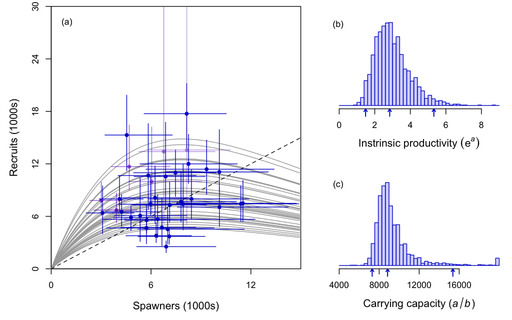

```r
layout(matrix(c(1,1,2,3),2,2),c(3,2),c(1,1))
CI_vec <- c(0.025,0.5,0.975)
offSet <- 0.06

## posterior of spawners
sDat <- apply(mod_fit$BUGSoutput$sims.list$Sp,2,quantile,CI_vec)
sDat <- sDat[,1:(n_yrs-age_min+n_fore)]
## posterior of recruits
rDat <- exp(apply(mod_fit$BUGSoutput$sims.list$tot_ln_Rec,2,quantile,CI_vec))
## median values for a & b
aa <- apply(mod_fit$BUGSoutput$sims.list$ln_Rkr_a,2,median)
bb <- apply(mod_fit$BUGSoutput$sims.list$Rkr_b,2,median)

## empty plot space for spawner-recruit relationships
dd <- 3000
yM <- Re2prec(max(rDat),"ceiling",dd)
yM <- 30000
xM <- Re2prec(max(sDat),"ceiling",dd)
par(mai=c(0.8,0.8,0.1,0.1), omi=c(0,0,0,0))
plot(sDat[2,],rDat[2,], xlim=c(0,xM), ylim=c(0,yM), pch=16, col="blue3", type="n",
     xaxs="i", yaxs="i", ylab="Recruits (1000s)", xlab="Spawners (1000s)", cex.lab=1.2,
     xaxt="n", yaxt="n")
axis(1, at=seq(0,xM,dd*2), labels=seq(0,xM,dd*2)/1000)
axis(2, at=seq(0,yM,dd*2), labels=seq(0,yM,dd*2)/1000)
for(i in 1:length(aa)) { lines(seq(xM)*exp(aa[i]-bb*seq(xM)), col="darkgray") }
## add S-R estimates and medians
abline(a=0,b=1,lty="dashed")
nCB <- n_yrs-age_max
points(sDat[2,1:nCB],rDat[2,1:nCB], xlim=c(0,xM), ylim=c(0,yM), pch=16, col="blue3")
segments(sDat[2,1:nCB],rDat[1,1:nCB],sDat[2,1:nCB],rDat[3,1:nCB], col="blue3")
segments(sDat[1,1:nCB],rDat[2,1:nCB],sDat[3,1:nCB],rDat[2,1:nCB], col="blue3")
nTB <- dim(sDat)[2]
clr <- rgb(100, 0, 200, alpha=seq(200,100,length.out=age_max-age_min+n_fore), maxColorValue=255)
segments(sDat[2,(nCB+1):nTB],rDat[1,(nCB+1):nTB],sDat[2,(nCB+1):nTB],rDat[3,(nCB+1):nTB], col=clr)
segments(sDat[1,(nCB+1):nTB],rDat[2,(nCB+1):nTB],sDat[3,(nCB+1):nTB],rDat[2,(nCB+1):nTB], col=clr)
points(sDat[2,(nCB+1):nTB],rDat[2,(nCB+1):nTB],
       xlim=c(0,xM), ylim=c(0,yM), pch=16, col=clr)
text(x=par()$usr[1]+par()$pin[2]/par()$pin[1]*offSet*diff(par()$usr[1:2]),
     y=par()$usr[4]-offSet*diff(par()$usr[3:4]),"(a)")

## posterior for exp(a)
clr <- rgb(0, 0, 255, alpha = 50, maxColorValue = 255)
par(mai=c(0.8,0.4,0.3,0.1))
## Ricker a
R_alpha_est <- mod_fit$BUGSoutput$sims.list$alpha
alphaCI <- quantile(R_alpha_est,c(0.025,0.5,0.975))
R_alpha_est[R_alpha_est>9] <- 9
hist(R_alpha_est,freq=FALSE,xlab="",main="",breaks=seq(0,9,0.2),
     col=clr, border="blue3", ylab="", cex.lab=1.2, yaxt="n")
aHt <- (par()$usr[4]-par()$usr[3])/12
arrows(alphaCI,par()$usr[3],alphaCI,par()$usr[3]-aHt,
       code=1,length=0.05,xpd=NA,col="blue3",lwd=1.5)
mtext(expression(paste("Instrinsic productivity ",(e^italic(a)))), 1, line=3, cex=1)
text(x=par()$usr[1]+par()$pin[2]/par()$pin[1]*offSet*diff(par()$usr[1:2]),
     y=par()$usr[4]-offSet*diff(par()$usr[3:4]),"(b)")

## posterior for a/b
par(mai=c(0.8,0.4,0.3,0.1))
aa <- matrix(mod_fit$BUGSoutput$sims.array[,,"E_Rkr_a"],ncol=1)
bb <- matrix(mod_fit$BUGSoutput$sims.array[,,"Rkr_b"],ncol=1)
R_b_est <- aa/bb
R_b_est <- R_b_est[R_b_est > 0]
R_b_CI <- quantile(R_b_est,c(0.025,0.5,0.975))
R_b_est[R_b_est>2e4] <- 2e4
brks <- seq(Re2prec(min(R_b_est),"floor",2000),2e4,length.out=length(seq(0,9,0.2)))
hist(R_b_est, freq=FALSE, breaks=brks, col=clr, border="blue3",
     xlab="", xaxt="n", yaxt="n",
     main="", ylab="", cex.lab=1.2)
axis(1, at=seq(Re2prec(min(R_b_est),"floor",2000),1.8e4,4000))
aHt <- (par()$usr[4]-par()$usr[3])/12
arrows(R_b_CI,par()$usr[3],R_b_CI,par()$usr[3]-aHt,
       code=1,length=0.05,xpd=NA,col="blue3",lwd=1.5)
mtext(expression(paste("Carrying capacity (",italic(a)/italic(b),")")), 1, line=3, cex=1)
text(x=par()$usr[1]+par()$pin[2]/par()$pin[1]*offSet*diff(par()$usr[1:2]),
     y=par()$usr[4]-offSet*diff(par()$usr[3:4]),"(c)")
```

### Covariate effects

Here are time series plots of the covariates (a-e) and histograms of their effects on productivity (f-j).

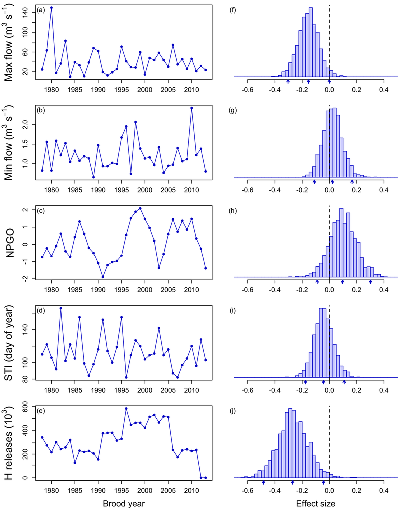

```r
clr <- rgb(0, 0, 255, alpha = 50, maxColorValue = 255)
offSet <- 0.07
c_est <- mod_fit$BUGSoutput$sims.list$cc
par(mfrow=c(n_cov,2), mai=c(0.4,0.2,0.1,0.1), omi=c(0.2,0.5,0,0))
ylN <- floor(min(c_est)*10)/10
ylM <- ceiling(max(c_est)*10)/10
brks <- seq(ylN,ylM,length.out=diff(c(ylN,ylM))*40+1)
cov_names <- c(expression(paste("Max flow (",m^3," ",s^{-1},")")),
               expression(paste("Min flow (",m^3," ",s^{-1},")")),
               "NPGO",
               "STI (day of year)",
               expression(paste("H releases (",10^3,")")))
t_idx <- seq(yr_frst,length.out=n_yrs-age_min+n_fore)
for(i in 1:n_cov) {
  if(i==5) {dat_cvrs[,i] <- dat_cvrs[,i]/1000}
    ## plot covar ts
    plot(t_idx, dat_cvrs[seq(length(t_idx)),i], xlab="", ylab="",
         main="", cex.axis=1.2, pch=16, col="blue3", type="o")
    text(x=par()$usr[1]+par()$pin[2]/par()$pin[1]*offSet*diff(par()$usr[1:2]),
         y=par()$usr[4]-offSet*diff(par()$usr[3:4]),paste0("(",letters[i],")"), cex=1.2)
    mtext(side=2, cov_names[i], line=3, cex=1.2)
    if(i==n_cov) { mtext(side=1,"Brood year", line=3) }
    ## plot covar effect
    hist(c_est[,i],
         freq=FALSE,breaks=brks,col=clr,border="blue3",
         xlab="", yaxt="n", main="", ylab="", cex.axis=1.2)
    c_CI <- quantile(c_est[,i],c(0.025,0.5,0.975))
    aHt <- (par()$usr[4]-par()$usr[3])/20
    arrows(c_CI,par()$usr[3]-0.005,c_CI,par()$usr[3]-aHt,
           code=1,length=0.05,xpd=NA,col="blue3",lwd=1.5)
    abline(v=0, lty="dashed")
    text(x=par()$usr[1]+par()$pin[2]/par()$pin[1]*offSet*diff(par()$usr[1:2]), cex=1.2,
         y=par()$usr[4]-offSet*diff(par()$usr[3:4]),paste0("(",letters[i+n_cov],")"))
    if(i==n_cov) { mtext(side=1,"Effect size", line=3) }
}
```

### Management reference points

Here are a number of management reference points.

```r
# abbreviations for ref points
ref_names <- c("MSY","Smsy","Umsy","Umax")
# proportions of MSY to consider
yld_prop <- c(0.75,0.85,0.95)
aa <- matrix(mod_fit$BUGSoutput$sims.array[,,"E_Rkr_a"],ncol=1)
alpha <- matrix(mod_fit$BUGSoutput$sims.array[,,"alpha"],ncol=1)
mcmc <- length(aa)
# empty matrix for ref pts
ref.pts <- matrix(NA,mcmc,length(ref_names))
colnames(ref.pts) <- ref_names
# spawner series for optimal yield profile
SS <- seq(100,1e4,100)
# empty matrix for optimal yield profiles
OYP <- matrix(0,length(SS),length(yld_prop))
for(i in 1:mcmc) {
    # spawners at MSY
    ref.pts[i,"Smsy"] <- (1 - lambert_W0(exp(1-aa[i]))) / bb[i]
    # MSY
    ref.pts[i,"MSY"] <- ref.pts[i,"Smsy"]*((exp(aa[i]-bb[i]*ref.pts[i,"Smsy"])) - 1)
    # harvest rate at MSY
    ref.pts[i,"Umsy"] <- (1 - lambert_W0(exp(1-aa[i])))
    # max harvest rate
    ref.pts[i,"Umax"] <- 1 - 1/alpha[i]
    # yield over varying S
    yield <- SS*(exp(aa[i]-bb[i]*SS) - 1)
    for(j in 1:length(yld_prop)) {
        OYP[,j] <- OYP[,j] + 1*(yield > yld_prop[j]*ref.pts[i,"MSY"])
    }
}
OYP <- OYP/mcmc

## Prob of overfishing
hh <- seq(100)
Pr_over <- cbind(hh,hh,hh)
colnames(Pr_over) <- c("Umsy75","Umsy","Umax")
for(i in hh) {
  Pr_over[i,"Umsy75"] <- sum(ref.pts[,"Umsy"]*0.75 < i/100)/mcmc_samp
  Pr_over[i,"Umsy"] <- sum(ref.pts[,"Umsy"] < i/100)/mcmc_samp
  Pr_over[i,"Umax"] <- sum(ref.pts[,"Umax"] < i/100)/mcmc_samp
}

## posterior exploitation rate & spawner abundance
aer <- Sp_ts <- mod_fit$BUGSoutput$sims.list$Sp[,1:n_yrs]
for(i in 1:n_yrs) {
    aer[,i] <- dat_harv[i] / (dat_harv[i] + Sp_ts[,i])
}
```

These are plots of (a) the probability that a given number of spawners produce average yields exceeding X% of MSY (i.e, optimal yield profiles); and (b) the cumulative probabilty of overfishing the population, based on harvest rates equal to those at 75% of MSY $(U_{\text{M75}})$, MSY $(U_{\text{MSY}})$, and the maximum $(U_{\text{Max}})$. The probability of exceeding $U_{\text{Max}}$ indicates the risk that offspring will not replace their parents, which, if sustained, will lead to eventual extinction. The histograms above (a) and (b) are distributions of the posterior estimates for the number of spawners and harvest rates, respectively.

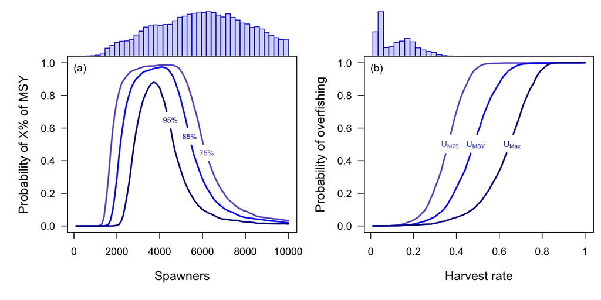

```r
layout(matrix(c(2,1,4,3),2,2),heights=c(1,5))

## OYP
par(mai=c(0.9,0.9,0,0), omi=c(0,0,0.1,0.1))
x_lp <- yld_prop
for(i in 1:length(x_lp)) {
    x_lp[i] <- SS[max(which(OYP[,i] == max(OYP[,i]) | abs(OYP[,i] - (yld_prop[i]-0.3)) <= 0.05))]
}
matplot(SS, OYP, type="l", lty="solid", las=1, col=c("slateblue","blue","darkblue"), lwd=2,
        xlab="Spawners", ylab="Probability of X% of MSY", cex.lab=1.2,
        main="", ylim=c(0,1))
points(x=x_lp, y=yld_prop-0.3, pch=21, cex=3.5, col="white", bg="white")
text(x=x_lp, y=yld_prop-0.3, paste0(yld_prop*100,"%"),
     col=c("slateblue","blue","darkblue"), cex=0.7)
text(x=par()$usr[1]+par()$pin[2]/par()$pin[1]*offSet*diff(par()$usr[1:2]),
     y=par()$usr[4]-offSet*diff(par()$usr[3:4]),"(a)")
## posterior spawner abundance over all years
par(mai=c(0,0.9,0.05,0))
hist(Sp_ts[Sp_ts<1e4], col=clr, border="blue3", breaks=40,
      main="", yaxs="i", xaxt="n",yaxt="n",ylab="")

## prob of overfishing
par(mai=c(0.9,0.9,0,0))
matplot(Pr_over, type="l", las=1, lwd=2, lty="solid", col=c("slateblue","blue","darkblue"),
        ylab="Probability of overfishing", cex.lab=1.2,
        xlab="Harvest rate", xaxt="n")
axis(1,seq(0,100,20),seq(0,100,20)/100)
x_lp <- c(0,0,0)
for(i in 1:length(x_lp)) {
    x_lp[i] <- max(which(abs(Pr_over[,i] - 0.5) <= 0.05))
}
points(x=x_lp, y=rep(0.5,3), pch=21, cex=4, col="white", bg="white")
text(x=x_lp, y=0.5, expression(U[M75], U[MSY], U[Max]),
     col=c("slateblue","blue","darkblue"), cex=0.8)
text(x=par()$usr[1]+par()$pin[2]/par()$pin[1]*offSet*diff(par()$usr[1:2]),
     y=par()$usr[4]-offSet*diff(par()$usr[3:4]),"(b)")
## posterior harvest rates over all years
par(mai=c(0,0.9,0.05,0))
hist(aer, col=clr, border="blue3", breaks=seq(0,40)/40,
      main="", yaxs="i", xaxt="n",yaxt="n",ylab="")
```

### Total population size

Here is our estimate of the total run size (i.e., catch + escapement) over time, which includes a forecast for 2016. The black points are the data, the blue line is the median posterior estimate, and the shaded region is the 95% credible interval. Note that the y-axis is on a log scale.

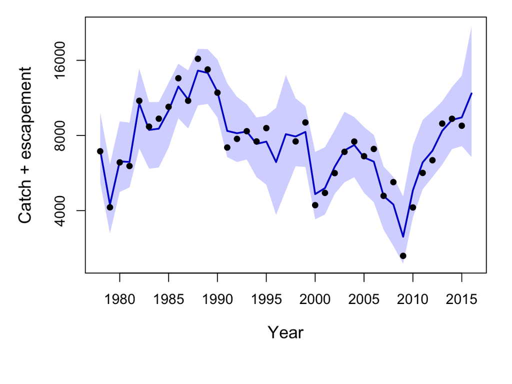

```r
pDat <- apply(mod_fit$BUGSoutput$sims.list$Sp,2,quantile,probs=CI_vec)
pDat <- pDat + matrix(dat_harv,length(CI_vec),n_yrs+n_fore,byrow=TRUE)
t_idx_f <- seq(yr_frst,length.out=n_yrs+n_fore)
ypMin <- min(pDat)
ypMax <- max(pDat)
par(mai=c(0.8,0.8,0.1,0.1), omi=c(0.5,0.2,0.1,0.2))
plot(t_idx_f,pDat[3,], ylim=c(ypMin,ypMax), type="n", log="y", xaxt="n", yaxt="n",
     xlab="Year", ylab="Catch + escapement", main="", cex.lab=1.2)
polygon(c(t_idx_f,rev(t_idx_f)),c(pDat[3,],rev(pDat[1,])), col=clr, border=NA)
lines(t_idx_f, pDat[2,], col="blue3", lwd=2)
points(t_idx_f, exp(ln_dat_esc)+dat_harv, pch=16, cex=1)
axis(1,at=seq(1980,2015,5))
axis(2,at=c(4000,8000,16000))
```

Here are several percentiles for the 2016 forecast for the total run size (i.e., catch + escapement).

```r
data.frame(forecast=round(quantile(mod_fit$BUGSoutput$sims.list$Sp[,n_yrs+n_fore],
                                   probs=c(0.025,0.25,0.5,0.75,0.975))))
```

```
##       forecast
## 2.5%      6554
## 25%       9727
## 50%      11789
## 75%      14362
## 97.5%    21848
```

### Correlation of innovations & SAR

Here is our estimate of the correlation between the model innovations (i.e, process residuals) and the smolt-to-adult return rate (i.e., logit transformed proportion of smolts that survive to adulthood) of hatchery steelhead from the Skagit R (Neala Kendall, WDFW, Olympia, WA, unpublished data). This gives an indication as to whether the unexplained variance in the productivity of wild fish might be related to the marine environment.

```r
## get SAR data
dat_SAR <- read.csv(text = getURL(paste0(ex_url,"SkagitHatcherySAR.csv")))
## match brood yr to smolt outmigration yr
dat_SAR$br_yr <- dat_SAR$out_yr - 2
## get innov
innov <- t(mod_fit$BUGSoutput$sims.list$res_ln_Rec)
## trim to same brood yrs as SAR data
innov <- innov[t_idx %in% dat_SAR$br_yr,]
## compute correlation over all mcmc samples
cor_vec <- apply(innov,2,function(x) { cor(qlogis(dat_SAR$SAR),x) })
## print median -/+ 95% credible interval
print(quantile(cor_vec,CI_vec), digits=2)
```

```
##  2.5%   50% 97.5%
## 0.028 0.301 0.535
```

## Additional results

The following results are not reported in the main manuscript, but are presented here as additional examples of other model estimates.

### Spawners over time

Here is the estimate of the number of spawners over time. The black points are the data, the blue line is the median posterior estimate, and the shaded region is the 95% credible interval. Note that there are no estimates of spawners in 1996 & 1997.

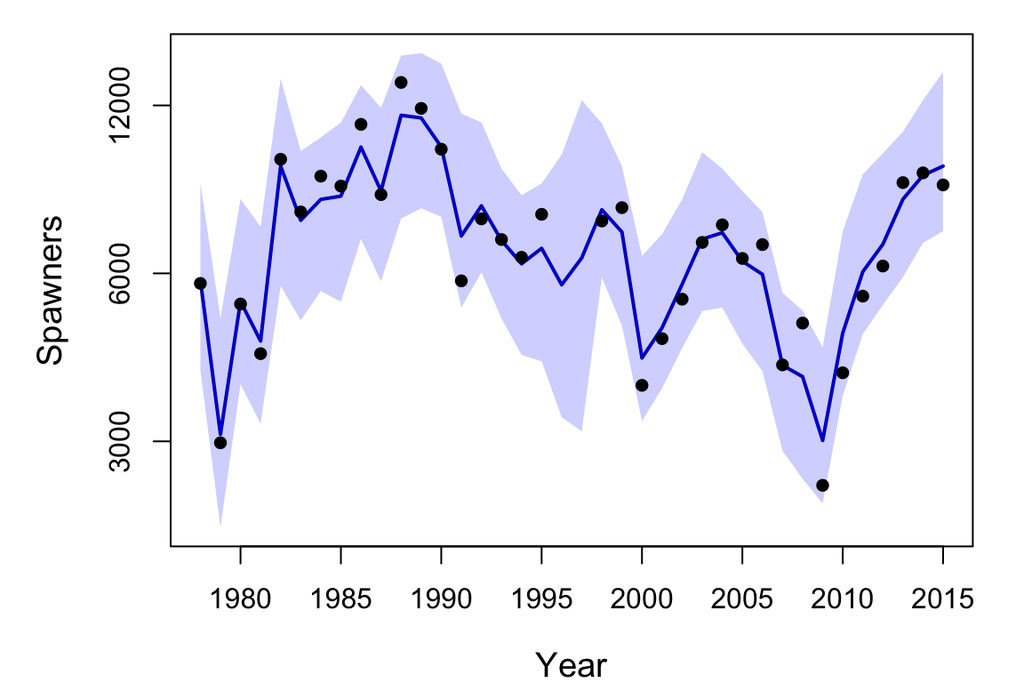

```r
pDat <- apply(mod_fit$BUGSoutput$sims.list$Sp,2,quantile,CI_vec)
ypMin <- min(pDat[,1:n_yrs])
ypMax <- max(pDat[,1:n_yrs])
t_idx_T <- seq(yr_frst,length.out=n_yrs)
par(mai=c(0.8,0.8,0.1,0.1), omi=c(0,0.2,0.1,0.2))
plot(t_idx_T,pDat[3,1:n_yrs], ylim=c(ypMin,ypMax), type="n", log="y", xaxt="n", yaxt="n",
     xlab="Year", ylab="Spawners", main="", cex.lab=1.2)
polygon(c(t_idx_T,rev(t_idx_T)),c(pDat[3,1:n_yrs],rev(pDat[1,1:n_yrs])), col=clr, border=NA)
lines(t_idx_T, pDat[2,1:n_yrs], col="blue3", lwd=2)
points(seq(yr_frst,length.out=n_yrs+n_fore), exp(ln_dat_esc), pch=16, cex=1)
axis(1,at=seq(1980,2015,5))
axis(2,at=c(3000,6000,12000))
```

### Recruits over time

Here are the estimated total number of recruits by brood year (note that the y-axis is on a log scale). Again the uncertainty increases in recent years because fewer complete age classes have been observed.

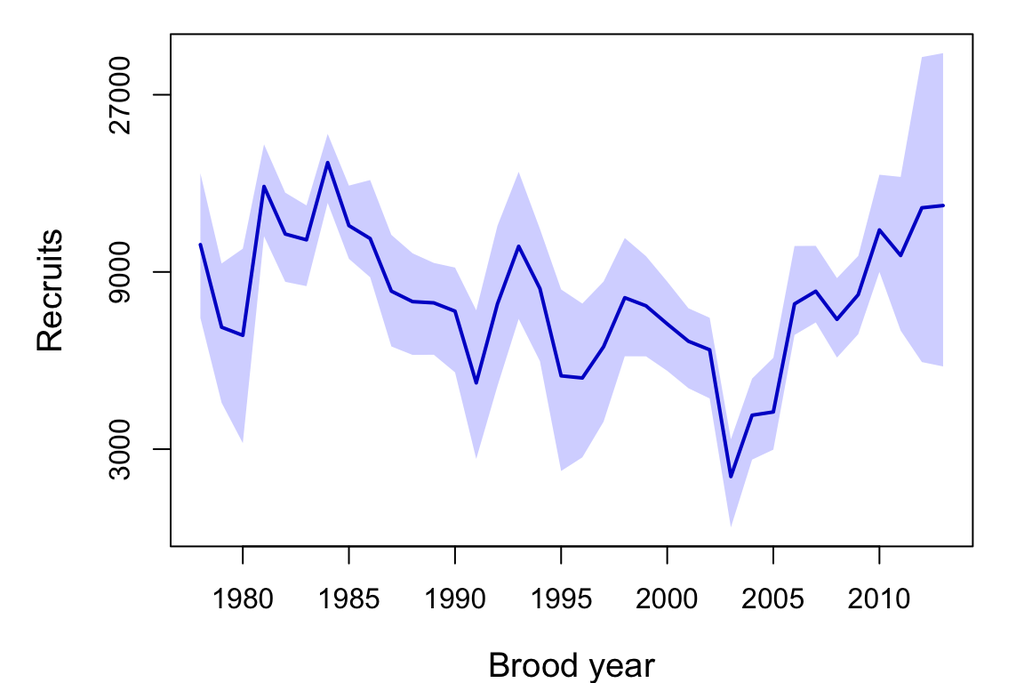

```r
CI_vec <- c(0.025,0.5,0.975)
pDat <- apply(mod_fit$BUGSoutput$sims.list$Rec,c(1,2),sum)
pDat <- apply(apply(pDat,2,sort),2,function(x) { x[mcmc_samp*CI_vec] })
ypMin <- min(pDat)
ypMax <- max(pDat)
t_idx_a <- seq(yr_frst,length.out=n_yrs-age_min+n_fore)
par(mai=c(0.8,0.8,0.1,0.1), omi=c(0,0.2,0.1,0.2))
plot(t_idx_a,pDat[3,], ylim=c(ypMin,ypMax), type="n", log="y", yaxt="n",
     xlab="Brood year", ylab="Recruits", main="", cex.lab=1.2)
axis(2,at=c(3000,9000,27000))
polygon(c(t_idx_a,rev(t_idx_a)),c(pDat[3,],rev(pDat[1,])), col=clr, border=NA)
lines(t_idx_a, pDat[2,], col="blue3", lwd=2)
```

### Recruits per spawner

Here is the time series of estimated recruits-per-spawner. Values above (below) the dashed line at zero indicate positive (negative) population growth.

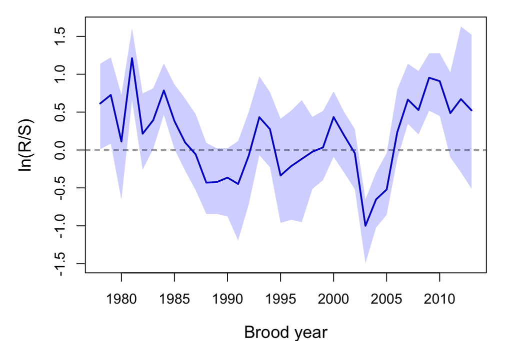

```r
pDat <- apply(mod_fit$BUGSoutput$sims.list$ln_RS,2,sort)
pDat <- apply(pDat,2,function(x) { x[mcmc_samp*CI_vec] })
pDat[2,] <- apply(mod_fit$BUGSoutput$sims.list$ln_RS,2,median)
ypMin <- min(pDat)
ypMax <- max(pDat)
par(mai=c(0.8,0.8,0.1,0.1), omi=c(0,0.2,0.1,0.2))
plot(t_idx_a,pDat[3,], ylim=c(ypMin,ypMax), type="n", #log="y",
     xlab="Brood year", ylab="ln(R/S)", main="", cex.lab=1.2)
abline(h=0, lty="dashed")
polygon(c(t_idx_a,rev(t_idx_a)),c(pDat[3,],rev(pDat[1,])), col=clr, border=NA)
lines(t_idx_a, pDat[2,], col="blue3", lwd=2)
```

### Age composition

Here are time series of the estimated proportions of each age class by brood year (cohort).

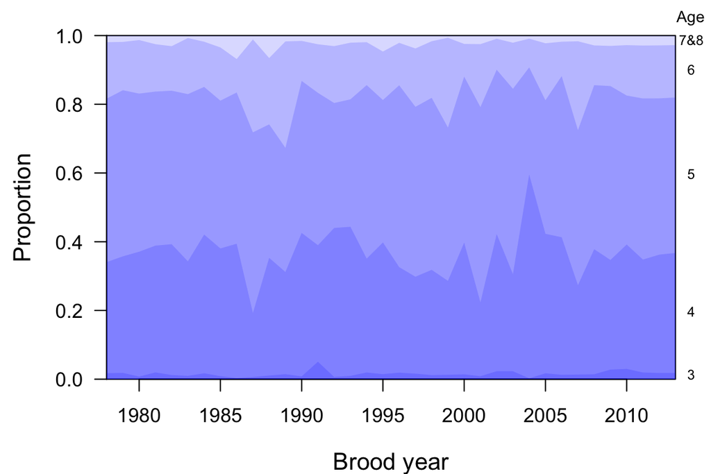

```r
par(mai=c(0.8,0.8,0.1,0.1), omi=c(0,0.1,0.2,0.2))
clr <- rgb(0, 0, 255, alpha = 40, maxColorValue = 255)
age_est <- t(apply(apply(mod_fit$BUGSoutput$sims.list$p_vec,c(3,2),mean),2,cumsum))
nRec <- n_yrs-age_min
plot(t_idx_a, rep(1,nRec+n_fore), ylab="Proportion", xlab="Brood year", ylim=c(0,1), las=1,
     xaxs="i", yaxs="i", type="n", lty="solid", col="blue3", cex.lab=1.2)
for(i in c(1,2,3,4,6)) {
    polygon(c(t_idx_a,rev(t_idx_a)),c(age_est[,i],rep(0,nRec+n_fore)), col=clr, border=NA)
    }
lbl <- apply(cbind(c(0,age_est[nRec+n_fore,-A]),age_est[nRec+n_fore,]),1,mean)
text(par()$usr[2],par()$usr[4]*1.05,"Age", xpd=NA, pos=4, offset=0.05, col="black", cex=0.8)
text(par()$usr[2],lbl[1:4],seq(3,6), xpd=NA, pos=4, col="black", cex=0.7)
text(par()$usr[2],lbl[5],"7&8", xpd=NA, pos=4, offset=0.15, col="black", cex=0.7)
```

### Recruits by age class

Here are the estimated number of recruits by brood year and age. Note that the uncertainty increases in recent years as fewer complete age classes have been observed.

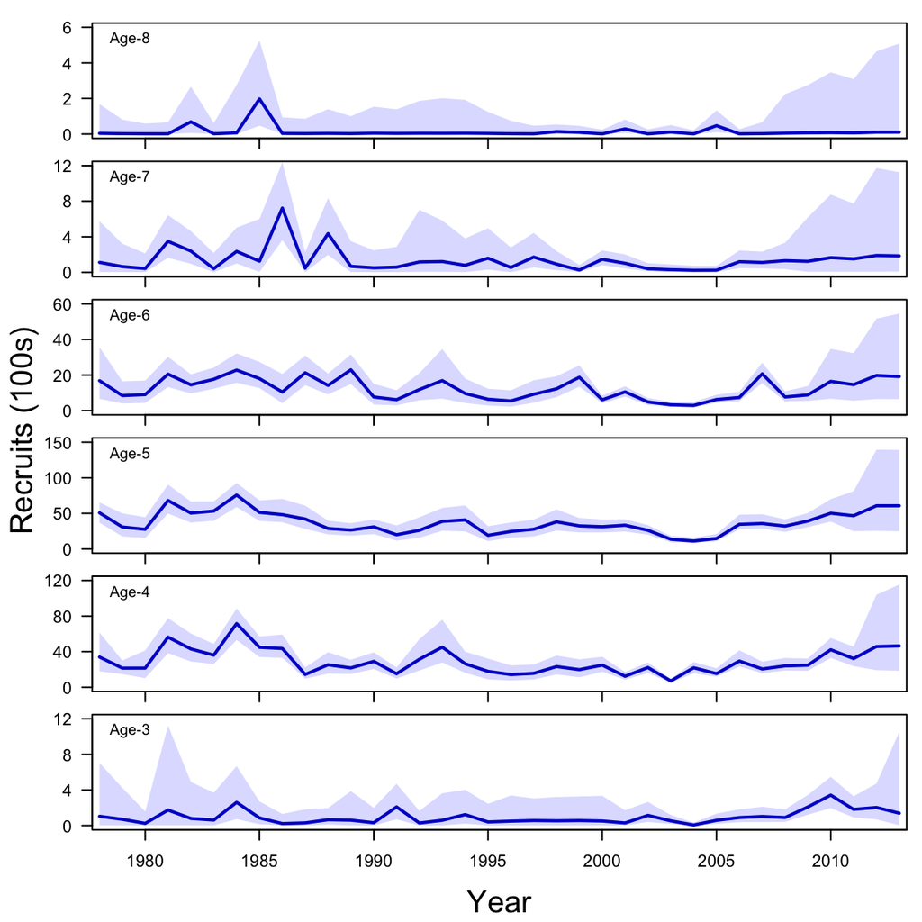

```r
CI_vec <- c(0.05,0.5,0.95)
par(mfrow=c(A,1), mai=c(0.1,0.1,0.05,0.1), omi=c(0.5,0.5,0.1,0))
t_idx_R <- seq(yr_frst,length.out=nRec+n_fore)
pltTT <- seq(min(round(t_idx_R/5,0)*5),max(round(t_idx_R/5,0)*5),5)
for(i in rev(1:A)) {
    pDat <- apply(mod_fit$BUGSoutput$sims.list$Rec[,,i],2,sort)
    pDat <- apply(pDat,2,function(x) { x[mcmc_samp*CI_vec] })/100
    dd <- ifelse(max(pDat)<20,1,10)
    ypMax <- Re2prec(max(pDat),prec=dd)
    while(ypMax %% 3 != 0) { ypMax <- ypMax + dd }
    plot(t_idx_R,pDat[3,], xlim=c(yr_frst+1,yr_last-n_fore-2), ylim=c(0.001,ypMax),
         type="n", xaxt="n", yaxt="n", xlab="", ylab="", main="", las=1)
    polygon(c(t_idx_R,rev(t_idx_R)),c(pDat[3,],rev(pDat[1,])), col=clr, border=NA)
    lines(t_idx_R, pDat[2,], col="blue3", lwd=2)
    aHt <- (par()$usr[4]-par()$usr[3])/7
    ttl <- paste("Age-",i+age_min-1,sep="")
    text(t_idx_R[1]-0, par()$usr[4]-aHt, ttl, pos=4, cex=0.9)
    axis(2,seq(0,ypMax,length.out=4),las=1,cex=0.9)
    if(i!=1) {axis(1,at=pltTT,labels=FALSE)} else {axis(1,at=pltTT)}
}
mtext("Recruits (100s)", 2, line=2, outer=TRUE, cex=1.2)
mtext("Year", 1, line=2.5, outer=TRUE, cex=1.2)
```

### Time-varying productivity

Here is the time series of the time-varying productivity ($a_t$), which includes the cumulative effects of the 5 covariates.

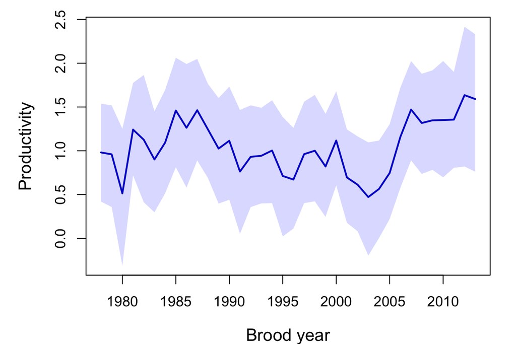

```r
pDat <- apply(mod_fit$BUGSoutput$sims.list$ln_Rkr_a,2,quantile,CI_vec)
ypMin <- min(pDat)
ypMax <- max(pDat)
par(mai=c(0.8,0.8,0.1,0.1), omi=c(0,0.2,0.1,0.2))
plot(t_idx_a,pDat[3,], ylim=c(ypMin,ypMax), type="n", #log="y",
     xlab="Brood year", ylab="Productivity", main="", cex.lab=1.2)
polygon(c(t_idx_a,rev(t_idx_a)),c(pDat[3,],rev(pDat[1,])), col=clr, border=NA)
lines(t_idx_a, pDat[2,], col="blue3", lwd=2)
```

### Innovations

Here is the time series of the so-called “innovations”, which are the residuals from the process model. They give some indication of population productivity after accounting for the effects of density dependence.

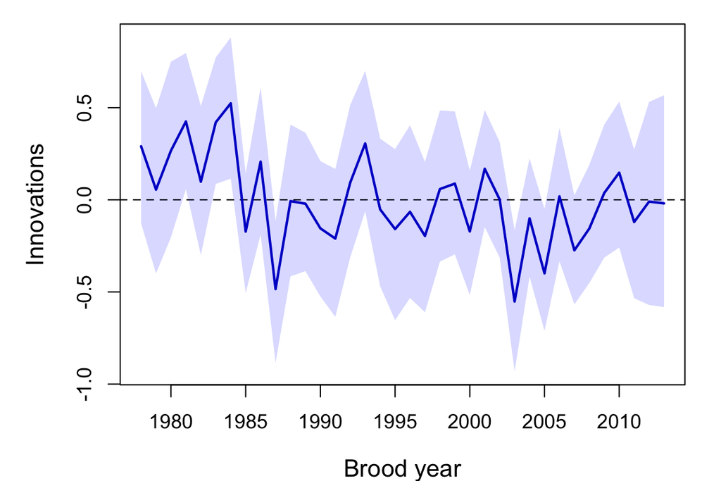

```r
pDat <- apply(mod_fit$BUGSoutput$sims.list$res_ln_Rec,2,quantile,CI_vec)
ypMin <- min(pDat)
ypMax <- max(pDat)
par(mai=c(0.8,0.8,0.1,0.1), omi=c(0,0.2,0.1,0.2))
plot(t_idx_a,pDat[3,], ylim=c(ypMin,ypMax), type="n", #log="y",
     xlab="Brood year", ylab="Innovations", main="", cex.lab=1.2)
abline(h=0, lty="dashed")
polygon(c(t_idx_a,rev(t_idx_a)),c(pDat[3,],rev(pDat[1,])), col=clr, border=NA)
lines(t_idx_a, pDat[2,], col="blue3", lwd=2)
```

## References

Dorner B, Peterman RM, Haeseker SL (2008) Historical trends in productivity of 120 pacific pink, chum, and sockeye salmon stocks reconstructed by using a kalman filter. Canadian Journal of Fisheries and Aquatic Sciences 65:1842–1866. doi: 10.1139/f08-094

Fleischman SJ, Catalano MJ, Clark RA, Bernard DR (2013) An age-structured state-space stock-recruit model for Pacific salmon (*Oncorhynchus* spp.). Canadian Journal of Fisheries and Aquatic Sciences 70:401–414. doi: 10.1139/cjfas-2012-0112

Peterman RM, Pyper BJ, MacGregor BW (2003) Use of the Kalman filter to reconstruct historical trends in productivity of Bristol Bay sockeye salmon (*Oncorhynchus nerka*). Canadian Journal of Fisheries and Aquatic Sciences 60:809–824. doi: 10.1139/f03-069